# Experience vs. description based decision-making project: Behavioral manipulation checks

# Set up environment and load in data

Add estimated model parameters and inferred bundle values using those parameters.

```r
clean_beh_data = add_inferred_pars(clean_beh_data, par_ests)
```

# Psychometric choice curves

Psychometric curve for all trials with weighted value difference. Q-values for the fractals and the weights for the two attributes are determined by the posterior means of the hierarchically fit two systems model. Blue lines indicate individual subjects.

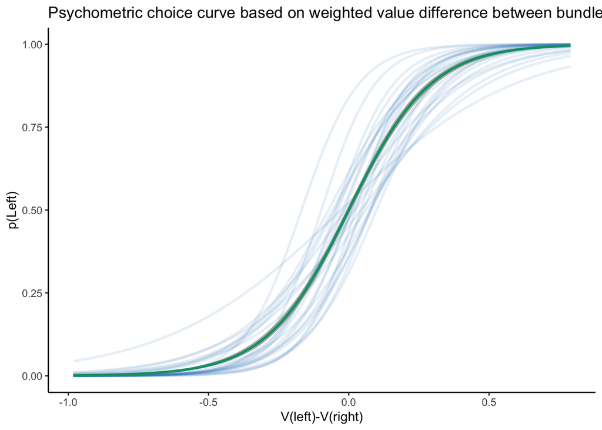

```r
clean_beh_data %>%
  ggplot(aes(leftBundleValAdv, choiceLeft))+
  geom_line(aes(group=subnum),stat="smooth",formula = 'y~x', method = "glm", method.args = list(family=binomial), fullrange=TRUE, se=FALSE, alpha=.1, size=1, color=cbbPalette[5])+
  geom_smooth(formula = 'y~x', method = "glm", method.args = list(family=binomial), fullrange=TRUE, color=cbbPalette[3], alpha=.75)+
  labs(y = "p(Left)", x = "V(left)-V(right)", title="Psychometric choice curve based on weighted value difference between bundles")
```

The dependence of choice on the bundle value difference holds for all levels of p(Frac) (not shown).

```r
clean_beh_data %>%
  ggplot(aes(leftbundleValAdv, choiceLeft))+
  geom_line(aes(group=subnum),stat="smooth",formula = 'y~x', method = "glm", method.args = list(family=binomial), fullrange=TRUE, se=FALSE, alpha=.1, size=1, color=cbbPalette[5])+
  geom_smooth(formula = 'y~x', method = "glm", method.args = list(family=binomial), fullrange=TRUE, color=cbbPalette[3], alpha=.75)+
  labs(y = "p(Left)", x = "V(left)-V(right)")+
  facet_grid(. ~ probFractalDraw)+
  theme(axis.ticks.x=element_blank(),
        axis.text.x=element_blank())
```

## Single relevant attribute trials

If subjects have understood the task then in these trials only the value difference of the relevant attribute should have an effect on choice. This is true on average as shown in the figure below but the blue lines depicting individual subjects suggest that there are individual differences in how much the choice relies on the Q-value difference even when it is the only relevant attribute. This will be explored more below.

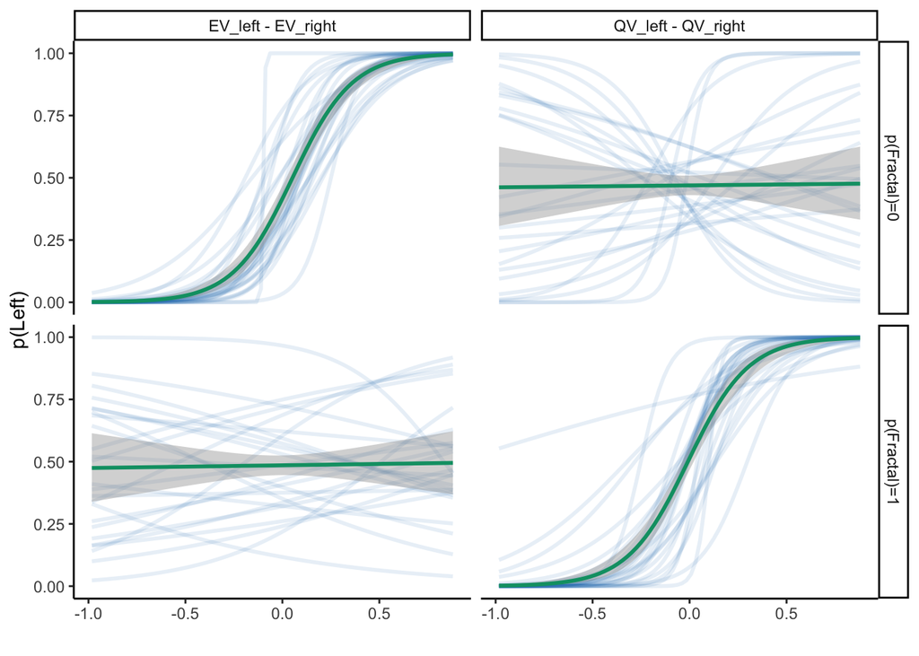

```r
clean_beh_data %>%
   filter(probFractalDraw == 1 | probFractalDraw == 0) %>%
  select(subnum, leftQVAdv, leftEVAdv, choiceLeft, probFractalDraw) %>%
  gather(key, value, -choiceLeft, -probFractalDraw, -subnum) %>%
  mutate(key = ifelse(key == "leftEVAdv", "EV_left - EV_right", "QV_left - QV_right"),
         probFractalDraw = ifelse(probFractalDraw == 0, "p(Fractal)=0", "p(Fractal)=1")) %>%
  ggplot(aes(value, choiceLeft))+
  # geom_jitter(width=0.03, height=0.08, alpha = 0.05)+
  geom_line(aes(group=subnum),stat='smooth',formula = 'y~x', method = "glm", method.args = list(family=binomial), fullrange=TRUE, se=FALSE, alpha=.1, size=1, color=cbbPalette[5])+
  geom_smooth(formula = 'y~x', method = "glm", method.args = list(family=binomial), fullrange=TRUE, color=cbbPalette[3])+
  facet_grid(probFractalDraw~key)+
  xlab("")+
  ylab("p(Left)")
```

```r
m1 = brm(choiceLeft ~ leftQVAdv + leftEVAdv + (1|subnum),
        data=tmp %>% filter(probFractalDraw == 0), family=bernoulli(link="logit"))
```

```r
summary(m1)
```

```r
m2 = brm(choiceLeft ~ leftQVAdv + leftEVAdv + (1|subnum),
        data=tmp %>% filter(probFractalDraw == 1), family=bernoulli(link="logit"))
```

```r
summary(m2)
```

```r
rm(tmp, m1, m2)
```

# Attribute weights

Since there are two attributes in each bundle the observed and learned values of these attributes can agree or disagree on which bundle is better to choose. Trials where the fractal and lottery value difference favors the same bundle are called *no conflict* trials and trials where they favor different bundles are called *conflict* trials.

The true weight of each attribute is controlled and determined by the probability that a trial’s reward would depend on a fractal or lottery draw. Subjects’ choice can, however, indicate that they distort these weights. If a subjective distortion of this sort exists it should be reflected in choice as a bias towards one attribute over the other.

In conflict trials:  
- when reward depends more on lotteries (p(Fractal)<.5) people correctly choose the bundle with the better lottery above chance.  
- when reward depends equally on both attributes (p(Fractal)=.5) people are slightly *biased* towards the bundle with the better lottery.  
- when reward depends more on fractals (p(Fractal)>.5) people choose the bundle with the better fractal more frequently than when the reward depended more on lotteries *but not as much as they choose the better lottery for the equivalent levels of relevance*

In no conflict trials:  
- when reward depends more or equally on lotteries people correctly choose the bundle that has both the better fractal and the better lottery.

Choice patterns for both conflict and no conflict trials when p(Fractal)>.5 suggests that subjects’ decision **correctly** relies less on the lottery and more on the fractal values but the inference about the inference about the fractal values is more error prone. This might be due to noise in the fractal value representation because it involves learning and cannot be read off the screen.

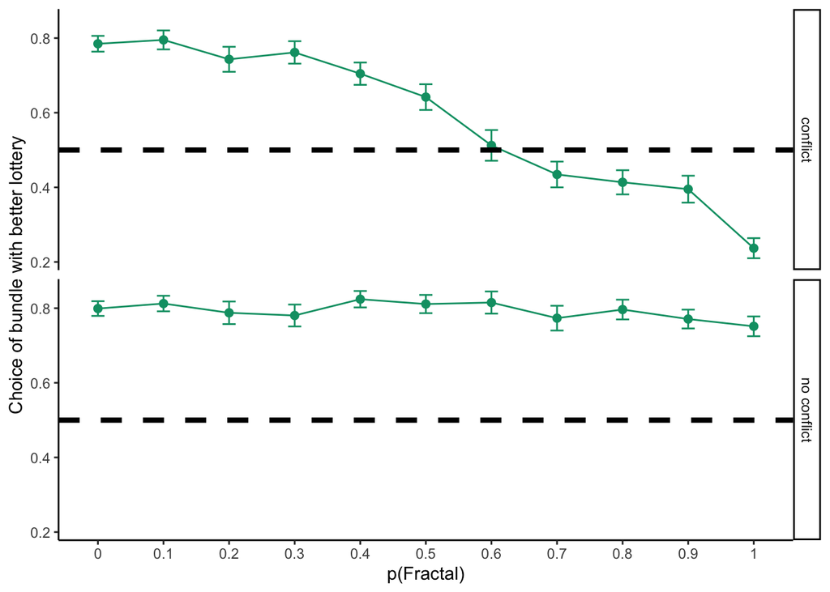

```r
clean_beh_data %>%
  group_by(probFractalDraw, subnum, conflictTrial) %>%
  summarise(choseBetterLottery = mean(choseBetterLottery),
            .groups='keep') %>%
  ungroup() %>%
  group_by(probFractalDraw, conflictTrial) %>%
  summarise(sem_choseBetterLottery = sem(choseBetterLottery),
            choseBetterLottery = mean(choseBetterLottery),
            .groups='keep') %>%
  ggplot(aes(as.factor(probFractalDraw), choseBetterLottery))+
  geom_point(color=cbbPalette[3], size = 2)+
  geom_errorbar(aes(ymax=choseBetterLottery + sem_choseBetterLottery, ymin=choseBetterLottery - sem_choseBetterLottery), width = 0.2, color=cbbPalette[3])+
  geom_line(group=1, color=cbbPalette[3])+
  geom_hline(yintercept=0.5, linetype="dashed", size=1.5)+
  facet_grid(conflictTrial~.)+
  labs(x="p(Fractal)",y="Choice of bundle with better lottery")
```

## Psychometric analysis

```r
source(paste0(helpers_path,'logit_choiceLeft_mixedEffects_conflictCollapsed.R'))
```

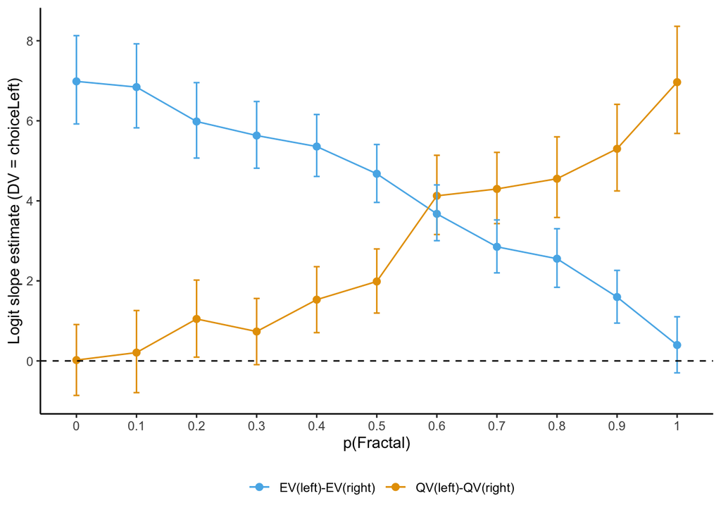

```r
out_choiceLeft %>%
  mutate(est = as.numeric(est),
         l95 = as.numeric(l95),
         u95 = as.numeric(u95)) %>%
  mutate(iv = ifelse(iv == "leftEVAdv", "EV(left)-EV(right)", "QV(left)-QV(right)")) %>%
  ggplot(aes(probFractalDraw, est, col=iv))+
  geom_point(size=2)+
  geom_line(aes(group=iv))+
  geom_errorbar(aes(ymin=l95, ymax=u95), width=0.1)+
  geom_hline(yintercept=0,linetype="dashed")+
  theme(legend.position = "bottom")+
  scale_color_manual(values=c(cbbPalette[2], cbbPalette[1]))+
  labs(color="", y="Logit slope estimate (DV = choiceLeft)", x="p(Fractal)")
```

## Determinants of the choice bias

```r
source(paste0(helpers_path,'logit_choiceLeft_randomEffects_conflictCollapsed.R'))
```

```r
#Plot of random effects similar to the logit slopes graph above

out_choiceLeft_re %>%
  filter(var %in% c("qv_slopes", "ev_slopes")) %>%
  mutate(probFractalDraw = as.factor(probFractalDraw),
         var = ifelse(var == "ev_slopes", "EV(left)-EV(right)", "QV(left)-QV(right)")) %>%
  ggplot(aes(probFractalDraw, Estimate, color=var, shape=var))+
  geom_point()+
  # geom_errorbar(aes(ymin=Q2.5, ymax=Q97.5), width=.1)+
  geom_hline(aes(yintercept=0), linetype="dashed")+
  # facet_grid(conflictTrial~.)+
  theme(legend.position = "bottom")+
  labs(color="", shape="", x="p(Fractal)", y="Logit slope estimate (DV = choiceLeft)")+
  scale_color_manual(values=c(cbbPalette[2], cbbPalette[1]))
```

```r
# A messier graph of the fast and slow learner difference in relying on the relevant attribute
clean_beh_data %>%
  group_by(subnum, probFractalDraw) %>%
  summarise(alpha=mean(alpha), .groups="keep") %>%
  left_join(out_choiceLeft_re %>%
              filter(var %in% c("qv_slopes", "ev_slopes")) %>%
              select(Estimate, subnum, var, probFractalDraw),
            by=c("subnum", "probFractalDraw")) %>%
  ggplot(aes(alpha, Estimate, color=var))+
  geom_smooth(formula = 'y~x', method = "lm",fullrange=TRUE)+
  geom_point(alpha=.5, size=.5)+
  facet_grid(.~probFractalDraw)+
  labs(color="", x="Learning rate", y="Logit slope estimate (DV = choiceLeft)")+
  scale_color_manual(values=c(cbbPalette[2], cbbPalette[1]))+
  theme(legend.position="bottom")
```

```r
clean_beh_data %>%
  group_by(subnum) %>%
  summarise(alpha=unique(alpha)) %>%
  ungroup() %>%
  mutate(alpha_group = ifelse(alpha>median(alpha), "fast learner", "slow learner")) %>%
  ggplot(aes(alpha, fill=alpha_group))+
  geom_histogram(alpha=.5, position = "identity", bins = 5)+
  scale_fill_manual(values=c(cbbPalette[3], cbbPalette[7]))+
  theme(legend.position = "bottom")+
  labs(fill="", x="Learning rate")
```

The logit analysis confirmed that subjects largely relied on the relevant attribute regardless of conflict or relevant attribute type. To check the second part of the hypothesis that the inference is more error-prone when the relevant attribute is fractals due to noise in the learning process we examined the relationship between learning rates and the choice bias.

To do this we median split the sample based on learning rates and ran a random effects analysis collapsing across conflict conditions.

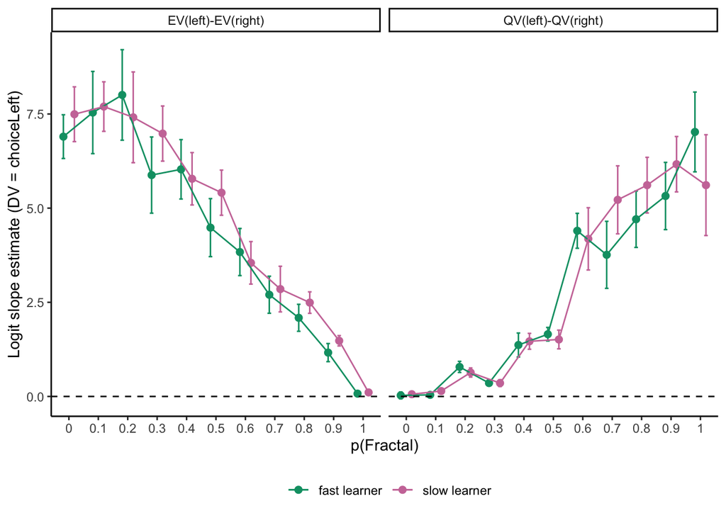

```r
clean_beh_data %>%
  group_by(subnum, probFractalDraw) %>%
  summarise(alpha=mean(alpha), .groups="keep") %>%
  left_join(out_choiceLeft_re %>%
              filter(var %in% c("qv_slopes", "ev_slopes")) %>%
              select(Estimate, subnum, var, probFractalDraw),
            by=c("subnum", "probFractalDraw")) %>%
  ungroup() %>%
  mutate(alpha_group = ifelse(alpha > median(alpha), "fast learner", "slow learner"),
         var = ifelse(var == "qv_slopes", "QV(left)-QV(right)",  "EV(left)-EV(right)")) %>%
  group_by(var, alpha_group, probFractalDraw) %>%
  summarise(mean_est = mean(Estimate),
            sem_est = sem(Estimate), .groups='keep') %>%
  ggplot(aes(as.factor(probFractalDraw), mean_est, col=alpha_group))+
    geom_point(position=position_dodge(width=0.75), size=2)+
    geom_errorbar(aes(ymin = mean_est - sem_est, ymax = mean_est+sem_est), width=0.25, position=position_dodge(width=0.75))+
  geom_line(aes(group=alpha_group), position=position_dodge(width=0.75))+
  geom_hline(aes(yintercept=0), linetype="dashed")+
 facet_grid(.~var)+
  labs(color="", x="p(Fractal)", y="Logit slope estimate (DV = choiceLeft)")+
  scale_color_manual(values=c(cbbPalette[3], cbbPalette[7]))+
  theme(legend.position="bottom")
```

```r
source(paste0(helpers_path,'fit_twoValSystemsWithRL_hierarchical_noProbDistortion.R'))
source(paste0(helpers_path,'00_get_behavioral_data.R'))
clean_beh_data_noProbDistortion = beh_data %>%
  filter(responded == 1,
         reactionTime > .2)
rm(beh_data)
clean_beh_data_noProbDistortion = add_inferred_pars(clean_beh_data_noProbDistortion, par_ests_noProbDistortion)
source(paste0(helpers_path,'logit_choiceLeft_randomEffects_conflictCollapsed_noProbDistortion.R'))

clean_beh_data_noProbDistortion %>%
  group_by(subnum, probFractalDraw) %>%
  summarise(alpha=mean(alpha), .groups="keep") %>%
  left_join(out_choiceLeft_re_noProbDistortion %>%
              filter(var %in% c("qv_slopes", "ev_slopes")) %>%
              select(Estimate, subnum, var, probFractalDraw),
            by=c("subnum", "probFractalDraw")) %>%
  ungroup() %>%
  mutate(alpha_group = ifelse(alpha > median(alpha), "fast learner", "slow learner"),
         var = ifelse(var == "qv_slopes", "QV(left)-QV(right)",  "EV(left)-EV(right)")) %>%
  group_by(var, alpha_group, probFractalDraw) %>%
  summarise(mean_est = mean(Estimate),
            sem_est = sem(Estimate), .groups='keep') %>%
  ggplot(aes(as.factor(probFractalDraw), mean_est, col=alpha_group))+
    geom_point(position=position_dodge(width=0.75), size=2)+
    geom_errorbar(aes(ymin = mean_est - sem_est, ymax = mean_est+sem_est), width=0.25, position=position_dodge(width=0.75))+
    geom_line(aes(group=alpha_group), position=position_dodge(width=0.75))+
  geom_hline(aes(yintercept=0), linetype="dashed")+
 facet_grid(.~var)+
  labs(color="", x="p(Fractal)", y="Logit slope estimate (DV = choiceLeft)")+
  scale_color_manual(values=c(cbbPalette[3], cbbPalette[7]))+
  theme(legend.position="bottom")
```